# 통계계산입문 과제2

2019314199 김동환

## Q2

### (a)

```r
library(faraway)
fit1<-lm(total~expend+ratio,data=sat)
fit2<-lm(total~expend+ratio+salary,data=sat)
anova(fit1,fit2)
```

```
## Analysis of Variance Table
##
## Model 1: total ~ expend + ratio
## Model 2: total ~ expend + ratio + salary
##   Res.Df    RSS Df Sum of Sq      F  Pr(>F)
## 1     47 233443
## 2     46 216812  1     16631 3.5285 0.06667 .
## ---
## Signif. codes:  0 '***' 0.001 '**' 0.01 '*' 0.05 '.' 0.1 ' ' 1
```

#### p값이 0.06으로 유의수준 0.05 에서 H0 : βsalary = 0 를 기각할 수 없다.

### (b)

```r
fit1<-lm(total~I(salary+ratio+expend),data=sat)
fit2<-lm(total~salary+ratio+expend,data=sat)
anova(fit1,fit2)
```

```
## Analysis of Variance Table
##
## Model 1: total ~ I(salary + ratio + expend)
## Model 2: total ~ salary + ratio + expend
##   Res.Df    RSS Df Sum of Sq      F Pr(>F)
## 1     48 230208
## 2     46 216812  2     13396 1.4211 0.2518
```

#### p값이 0.2518로 유의수준 0.05 에서 H0 : βsalary = βratio = βexpend을 기각할 수 없다.

### H0 : βsalary = 0

```r
fit1<-lm(total~expend+ratio+takers,data=sat)
fit2<-lm(total~salary+expend+ratio+takers,data=sat)
anova(fit1,fit2)
```

```
## Analysis of Variance Table
##
## Model 1: total ~ expend + ratio + takers
## Model 2: total ~ salary + expend + ratio + takers
##   Res.Df   RSS Df Sum of Sq      F Pr(>F)
## 1     46 48627
## 2     45 48124  1    503.43 0.4707 0.4962
```

#### p값이 0.4962로 유의수준 0.05 에서 H0 : βsalary = 0 을 기각할 수 없다.

### H0 : βsalary = βratio = βexpend

```r
fit1<-lm(total~I(salary+expend+ratio)+takers,data=sat)
fit2<-lm(total~salary+expend+ratio+takers,data=sat)
anova(fit1,fit2)
```

```
## Analysis of Variance Table
##
## Model 1: total ~ I(salary + expend + ratio) + takers
## Model 2: total ~ salary + expend + ratio + takers
##   Res.Df   RSS Df Sum of Sq      F  Pr(>F)
## 1     47 55921
## 2     45 48124  2    7797.1 3.6455 0.03409 *
## ---
## Signif. codes:  0 '***' 0.001 '**' 0.01 '*' 0.05 '.' 0.1 ' ' 1
```

#### p값이 0.03으로 유의수준 0.05 에서 H0 : βsalary = βratio = βexpend를 기각할 수 있다.

#### (a)에서와 마찬가지로 H0 : βsalary = 0은 유의하지 않았음. 근데 (a)에서는 p값이 0.06으로 유의수준과 비교할 때, 연구자의 판단에 따라 유의하다고 할 만 하지만, (c)에서는0.49로 (a)와 차이가 심했음. (b)에서는 H0 : βsalary = βratio = βexpend를 기각 할 수 없었지만, (c)에서는 기각할 수 있다고 결과가 나왔음.

## Q3

### (a)

#### 예측된 회귀 모형 식

#### Species=13.75671+0.27355*Elevation-0.24922*Scruz-0.0663*Adjacent+0.23822*Nearest

#### “p-value:2.45e-07” 와 “F-statistic:19.23 on 4 and 25 DF” 이 설명하고 있는 가설검정과 그 결과 : 해당 가설 검정의 귀무가설은 모든 회귀계수가 0이다 이고, 대립가설 은 적어도 한개의 회귀계수는 0이 아니다이다. F값이 19.23이고 p-value가 0.05보다 작음으로 유의 수준 0.05에서 귀무가설을 기각한다. 즉 적어도 한 개의 회귀계수는 0이 아니다.

### (b)

```r
fit1<-lm(Species~Elevation+Adjacent,data=gala)
fit2<-lm(Species~Elevation+Scruz+Adjacent+Nearest,data=gala)
anova(fit1,fit2)
```

```
## Analysis of Variance Table
##
## Model 1: Species ~ Elevation + Adjacent
## Model 2: Species ~ Elevation + Scruz + Adjacent + Nearest
##   Res.Df    RSS Df Sum of Sq      F Pr(>F)
## 1     27 100003
## 2     25  93469  2    6533.9 0.8738 0.4297
```

#### 귀무가설은 H0 : βScruz = βNearest = 0이고, 결과 F값이 0.8738로 p값이 0.4297임으로 유의수준 0.05하에서 귀무가설을 기각할 수 없다.

### (c)

```r
fit1<-lm(Species~I(-4.5*Elevation+Adjacent)+Scruz+Nearest,data=gala)
fit2<-lm(Species~Elevation+Scruz+Adjacent+Nearest,data=gala)
anova(fit1,fit2)
```

```
## Analysis of Variance Table
##
## Model 1: Species ~ I(-4.5 * Elevation + Adjacent) + Scruz + Nearest
## Model 2: Species ~ Elevation + Scruz + Adjacent + Nearest
##   Res.Df   RSS Df Sum of Sq      F Pr(>F)
## 1     26 94169
## 2     25 93469  1    700.25 0.1873 0.6689
```

#### 귀무가설은 H0 : βElevation = -4.5*βAdjacent이고 검정결과 , F값이 0.1873, p값이 0.6689로 유의수준 0.1에서 귀무가설을 기각할 수 없다.

## Q4

### (a)

```r
library(glmnet)
x<-as.matrix(seatpos[,c(1:8)])
y<-as.matrix(seatpos[,9])
lam_set1=seq(0,100,1)
lam_set2=seq(0,10,0.1)
ridge=glmnet(x,y,family='gaussian',alpha=0,lambda=lam_set1)
lasso=glmnet(x,y,family='gaussian',alpha=1,lambda=lam_set2)
```

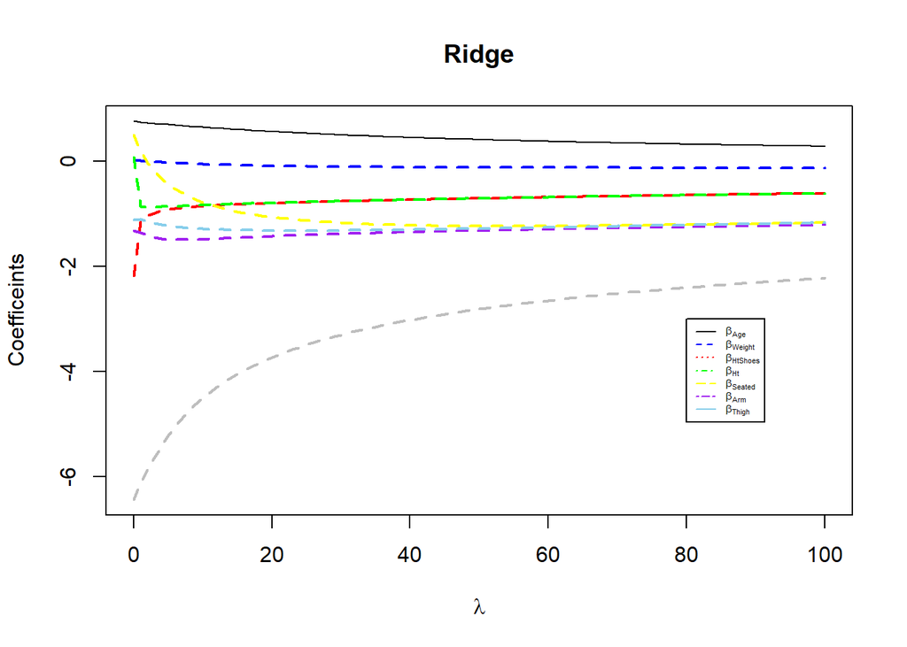

```r
####ridge
plot(lam_set1,rev(ridge$beta[1,]),type='l',xlim=range(lam_set1),ylim=range(ridge$beta),xlab=expression(lambda),ylab='Coefficeints',main='Ridge')
lines(lam_set1,rev(ridge$beta[2,]),col='blue',lty=2,lwd=2)
lines(lam_set1,rev(ridge$beta[3,]),col='red',lty=2,lwd=2)
lines(lam_set1,rev(ridge$beta[4,]),col='green',lty=2,lwd=2)
lines(lam_set1,rev(ridge$beta[5,]),col='yellow',lty=2,lwd=2)
lines(lam_set1,rev(ridge$beta[6,]),col='purple',lty=2,lwd=2)
lines(lam_set1,rev(ridge$beta[7,]),col='skyblue',lty=2,lwd=2)
lines(lam_set1,rev(ridge$beta[8,]),col='grey',lty=2,lwd=2)
legend(80,-3,legend=expression(beta[Age],beta[Weight],beta[HtShoes],beta[Ht],beta[Seated],beta[Arm],beta[Thigh]),col=c('black','blue','red','green','yellow','purple','skyblue','grey'),lty=1:8,cex=0.5)
```

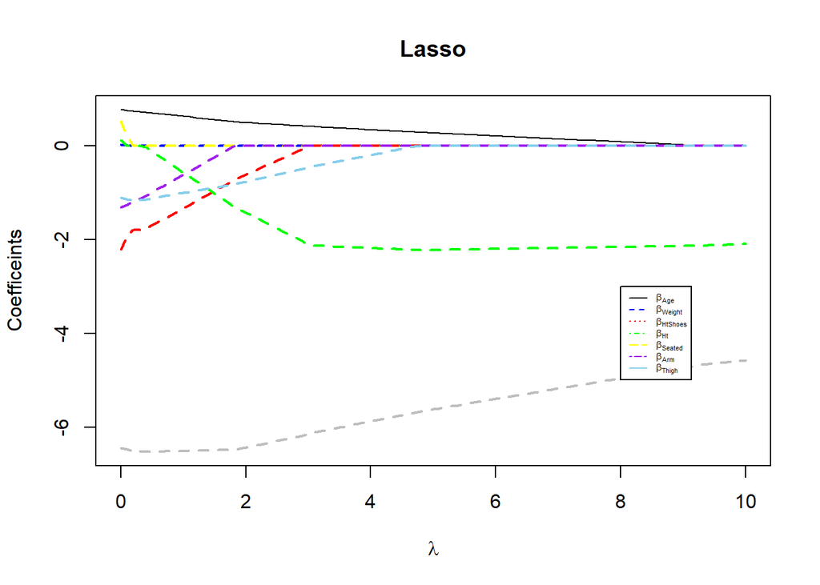

```r
####lasso
plot(lam_set2,rev(lasso$beta[1,]),type='l',xlim=range(lam_set2),ylim=range(lasso$beta),xlab=expression(lambda),ylab='Coefficeints',main='Lasso')
lines(lam_set2,rev(lasso$beta[2,]),col='blue',lty=2,lwd=2)
lines(lam_set2,rev(lasso$beta[3,]),col='red',lty=2,lwd=2)
lines(lam_set2,rev(lasso$beta[4,]),col='green',lty=2,lwd=2)
lines(lam_set2,rev(lasso$beta[5,]),col='yellow',lty=2,lwd=2)
lines(lam_set2,rev(lasso$beta[6,]),col='purple',lty=2,lwd=2)
lines(lam_set2,rev(lasso$beta[7,]),col='skyblue',lty=2,lwd=2)
lines(lam_set2,rev(lasso$beta[8,]),col='grey',lty=2,lwd=2)
legend(8,-3,legend=expression(beta[Age],beta[Weight],beta[HtShoes],beta[Ht],beta[Seated],beta[Arm],beta[Thigh]),col=c('black','blue','red','green','yellow','purple','skyblue','grey'),lty=1:8,cex=0.5)
```

### (b)

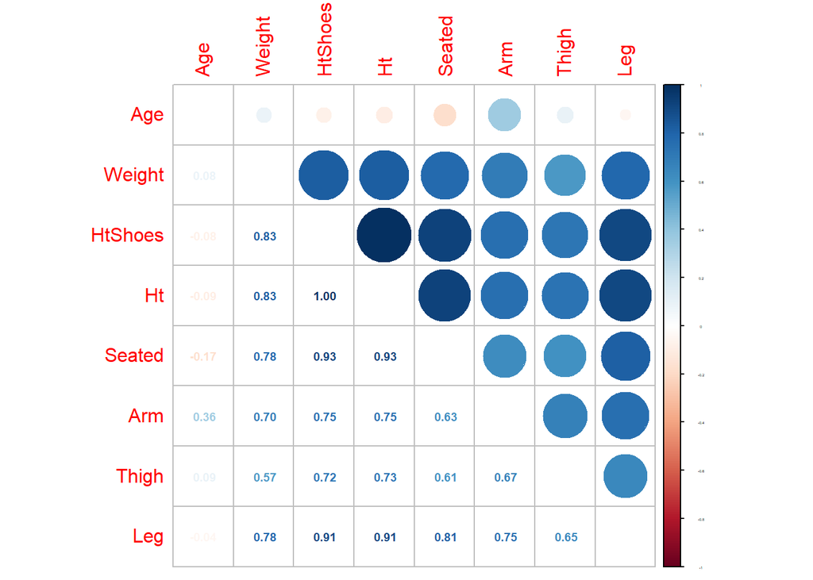

```r
library(corrplot)
corrplot.mixed(cor(x),lower='number',upper='circle',tl.pos='lt',cl.cex=0.2,number.cex=0.6)
```

#### Lasso는 L1정규화를 사용하는데 이는 모델에서 불필요한 변수의 계수를 0으로 들어 변수선택을 하는 경향으로 나타난다. 즉, Lasso는 이런 측면에서 변수 선택 기능을 제공한다고 볼 수 있다. 위의 상관관계 plot을 보면면 X변수간의 상관관계가 높은 것을 확인 할 수 있는데, 이 때문에 Lasso를 선택한다. Lasso를 선택함으로써 모델이 더 해석가능하고 간소화된 형태가 될 수 있다.

## Q5